# ai-analytic-04

Alex

2018-03-06

```r
source("2018-02-21-ai-analytics/BDVis.R")
source("2018-02-21-ai-analytics/UniVarAnal.R")
source("2018-02-21-ai-analytics/RiskPrediction.R")
CH1.demo<-readRDS("2018-02-21-ai-analytics/CH1.demo.RDS")
CH1.out<-readRDS("2018-02-21-ai-analytics/CH1.out.RDS")
pat.grp<-CH1.out[,1:2]
pat.grp$Death<-sapply(as.character(pat.grp$Death),function(x)switch(x,"0"="Alive","1"="Death"))
names(pat.grp)[2]<-"group"
CH1.demo<-left_join(CH1.demo,pat.grp)
mdl.strct<-readRDS("2018-02-21-ai-analytics/mdl.strct.RDS")
mdl.data<-readRDS("2018-02-21-ai-analytics/mdl.data.RDS")

#########################################################################
# Overview of dataset
#########################################################################

#Age distribution
vis.age<-age.vis(CH1.demo[,getcolumn("age",CH1.demo)])


#Gender distribution
cat.df<-col.aggr("gender",CH1.demo)
vis.gender<-cat.vis(cat.df,Title="Gender")


#Race distribution
cat.df<-col.aggr("Race",CH1.demo)
cat.df<-cat.df[c(1,3,2,4),]
vis.race<-cat.vis(cat.df,Title="Ethnicity")


#Marital status distribution
cat.df<-col.aggr("marital",CH1.demo)
cat.df$Var1[1]<-"Devorced"
cat.df<-cat.df[c(3,2,1,5,4),]
vis.marital<-cat.vis(cat.df,Title="Marital Status")


#Medifund distribution
cat.df<-col.aggr("mediFundHx",CH1.demo)
cat.df$Var1<-c("No","Yes")
cat.df<-cat.df[2:1,]
vis.medifund<-cat.vis(cat.df,Title="MediFund")



#Diabetes year distribution
cat.df<-col.aggr("Diabetes_year",CH1.demo)
cat.df<-cat.df[c(1,3:5,2),]
vis.diab.yr<-cat.vis(cat.df,Title="Diabetes Year")


#Patient type distribution
cat.df<-col.aggr("PAT_TYPE",CH1.demo)
vis.pat_type<-cat.vis(cat.df,Title="Patient type")



#Disease Prevalence
prev.df<-cols.aggr(CH1.demo[8:19])
prev.df$Disease[c(7,11,12)]<-c("Heart Failure","Major Amputation","Minor Amputation")
prev.df<-df.sort(prev.df)
vis.prev<-Prev.vis(prev.df)



#########################################################################
# Data Comparison by Outcome
#########################################################################

#Age distribution
vis.age.comp<-age.vis(CH1.demo[,getcolumn("age|group",CH1.demo)])
tab.age.comp<-coef.temp.func(CH1.demo,"age|group")


#Gender distribution
cat.df<-col.aggr("gender|group",CH1.demo)
vis.gender.comp<-cat.vis(cat.df,Title="Gender")
tab.gender.comp<-coef.temp.func(CH1.demo,"gender|group")


#Race distribution
cat.df<-col.aggr("Race|group",CH1.demo)
vis.race.comp<-cat.vis(cat.df,Title="Ethnicity")
tab.race.comp<-coef.temp.func(CH1.demo,"race|group")


#Marital status distribution
cat.df<-col.aggr("marital|group",CH1.demo)
cat.df[c(1,6),1]<-"Devorced"
vis.marital.comp<-cat.vis(cat.df,Title="Marital Status")
tab.marital.comp<-coef.temp.func(CH1.demo,"marital|group")


#Medifund distribution
cat.df<-col.aggr("mediFundHx|group",CH1.demo)
cat.df[,1]<-rep(c("No","Yes"),2)
vis.medifund.comp<-cat.vis(cat.df,Title="MediFund")
tab.medifund.comp<-coef.temp.func(CH1.demo,"mediFundHx|group")



#Diabetes year distribution
cat.df<-col.aggr("Diabetes_year|group",CH1.demo)
cat.df$Diabetes_year<-factor(cat.df$Diabetes_year,levels=cat.df[c(1,3:5,2),1])
vis.diab.yr.comp<-cat.vis(cat.df,Title="Diabetes Year")
tab.diab.yr.comp<-coef.temp.func(CH1.demo,"Diabetes_year|group")


#Patient type distribution
cat.df<-col.aggr("PAT_TYPE|group",CH1.demo)
vis.pat_type.comp<-cat.vis(cat.df,Title="Patient type")
tab.pat_type.comp<-coef.temp.func(CH1.demo,"PAT_TYPE|group")



#Disease Prevalence
demo.sub<-CH1.demo[,c(8:19,22)]
names(demo.sub)[c(7,11,12)]<-c("Heart Failure","Major Amputation","Minor Amputation")
prev.df<-cols.aggr(demo.sub)
prev.df<-df.sort(prev.df)
vis.prev.comp<-Prev.vis(prev.df)
```

## Data Overview

### Demographics

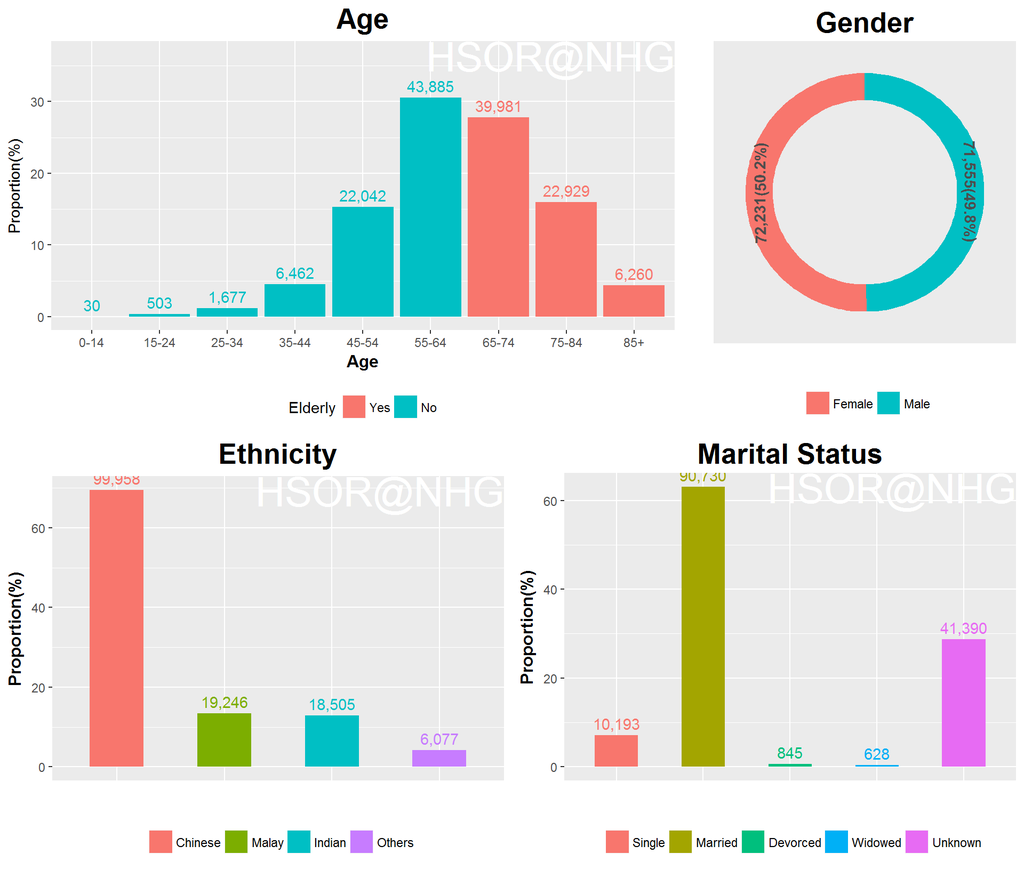

### Medical History

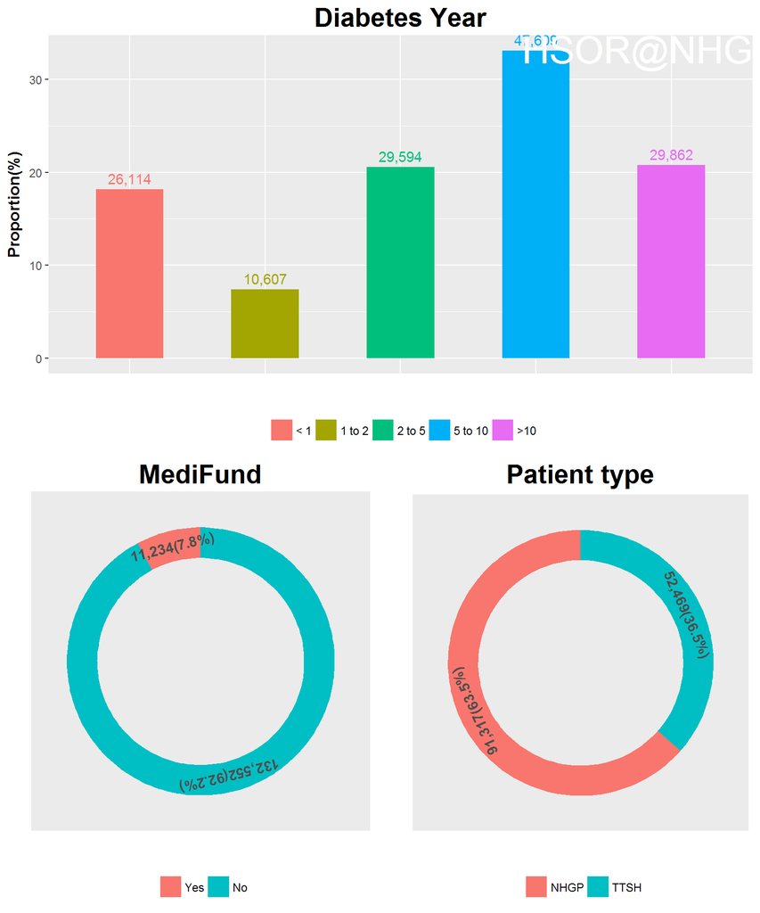

Disease prevalence

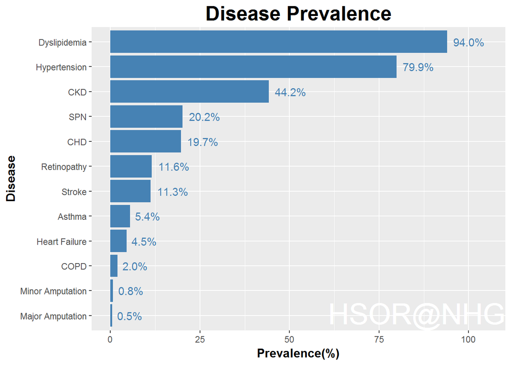

## Comparison by Ouctome

### Demographics

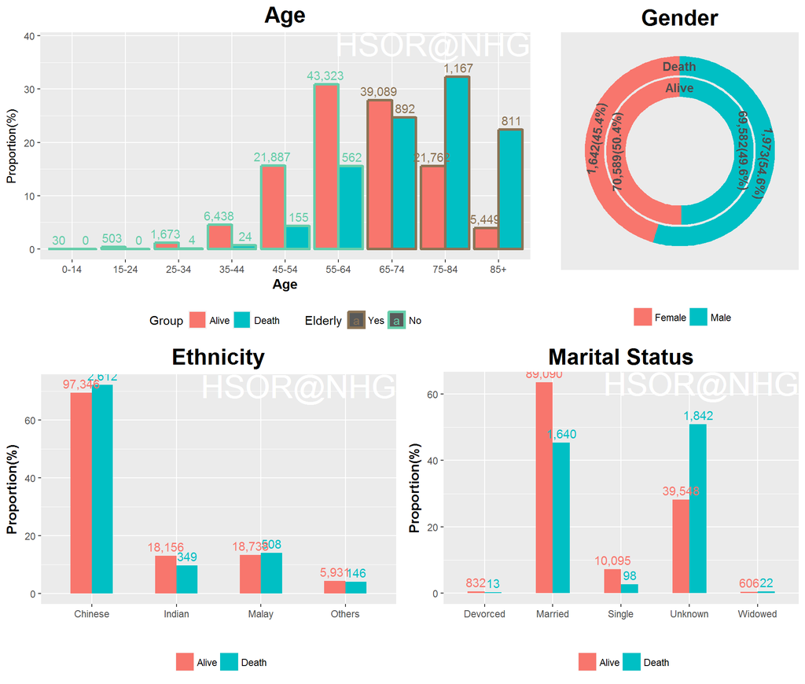

### Medical History

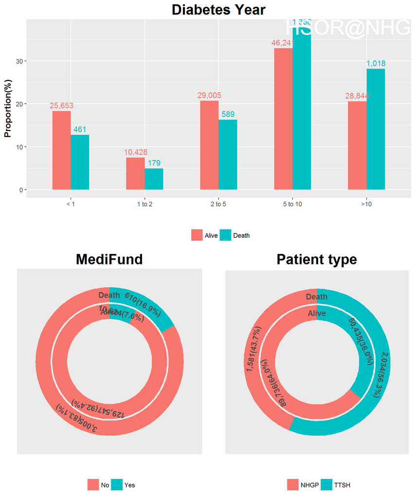

Disease prevalence

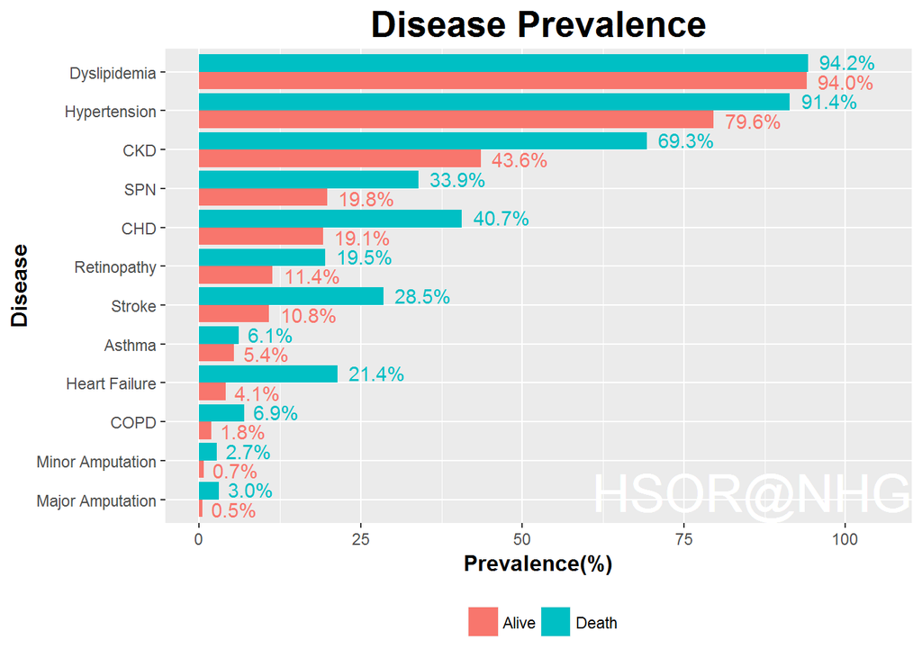

## Regression Analysis

### Coefficients

Variable

OddsRatio

Low95

Up95

Pvalue

Sig

Age

1.06

1.06

1.07

0.0000

***

**Gender**

Male

1.48

1.37

1.59

0.0000

***

**Race**

Chinese

0.92

0.77

1.10

0.3665

Malay

1.34

1.10

1.64

0.0034

Indian

0.92

0.74

1.13

0.4065

**Marital**

Single

0.47

0.38

0.58

0.0000

***

Divorced/Separated

0.61

0.35

1.08

0.0901

.

Widowed

0.57

0.36

0.90

0.0165

Married

0.52

0.48

0.56

0.0000

***

MediFund

1.38

1.25

1.54

0.0000

***

**DiabetesYear**

< 1

0.72

0.63

0.82

0.0000

***

1 to 2

0.78

0.65

0.92

0.0041

2 to 5

0.83

0.74

0.93

0.0011

5 to 10

0.93

0.85

1.02

0.1362

**PatType**

TTSH

0.70

0.61

0.80

0.0000

***

Dyslipidemia

0.74

0.63

0.88

0.0007

***

Hypertension

1.05

0.92

1.20

0.4852

Asthma

0.91

0.78

1.06

0.2125

COPD

1.37

1.18

1.61

0.0001

***

CKD

1.42

1.30

1.54

0.0000

***

CHD

1.14

1.05

1.24

0.0016

Heart_F

1.83

1.65

2.03

0.0000

***

Stroke

1.52

1.40

1.65

0.0000

***

Retinopathy

1.20

1.09

1.32

0.0001

***

SPN

1.28

1.18

1.39

0.0000

***

MajorAmputation

1.81

1.40

2.35

0.0000

***

MinorAmputation

1.22

0.94

1.58

0.1388

**BMI**

Underweight

1.02

0.84

1.23

0.8516

Normal

0.63

0.55

0.73

0.0000

***

Overweight

0.54

0.47

0.61

0.0000

***

Obese I

0.46

0.40

0.53

0.0000

***

Obese II

0.60

0.50

0.72

0.0000

***

Obese III

0.74

0.57

0.96

0.0233

**HbA1c**

<=5

2.46

1.78

3.40

0.0000

***

5.1-6

1.42

1.20

1.67

0.0000

***

6.1-7

0.95

0.81

1.12

0.5439

7.1-8.5

0.87

0.74

1.02

0.0837

.

>8.6

1.22

1.03

1.45

0.0200

**BP**

<120

0.86

0.74

1.01

0.0616

.

120-139

0.53

0.47

0.61

0.0000

***

140-159

0.52

0.45

0.59

0.0000

***

160-179

0.60

0.52

0.70

0.0000

***

>=180

0.61

0.52

0.73

0.0000

***

**LDL**

<2.6

0.57

0.49

0.67

0.0000

***

2.6-3.3

0.67

0.57

0.79

0.0000

***

3.4-4.0

0.67

0.55

0.82

0.0001

***

>=4.1

0.98

0.80

1.22

0.8857

SOC.score

2.78

1.85

4.16

0.0000

***

Diag.score

6.25

4.99

7.82

0.0000

***

Drug.score

6.26

4.73

8.29

0.0000

***

### Visualization of Coefficient

[figure not shown]

[figure not shown]

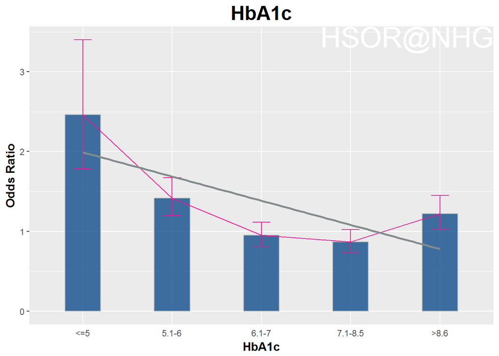

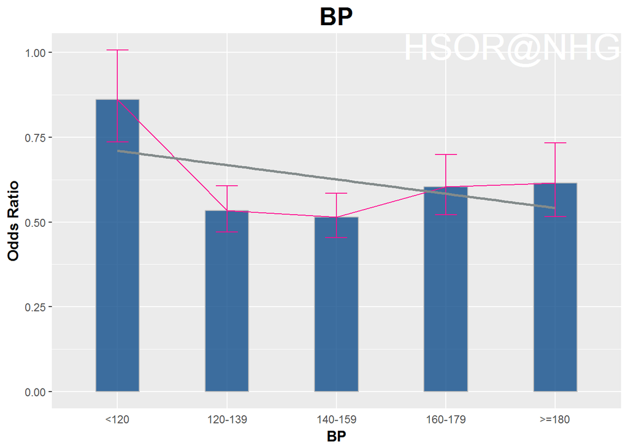

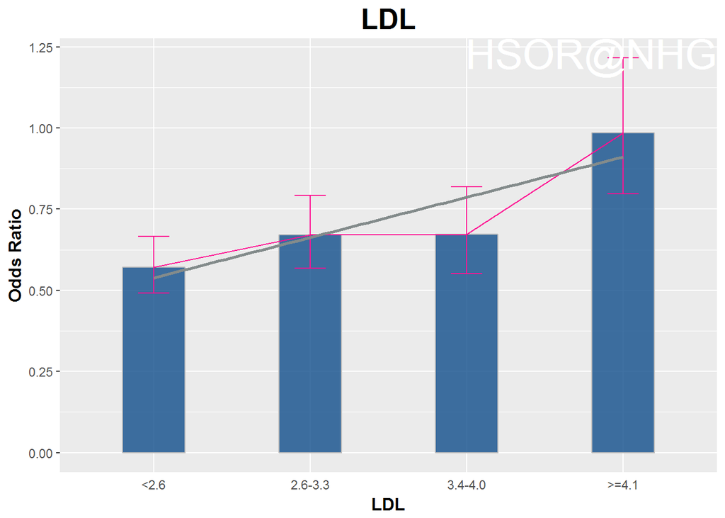

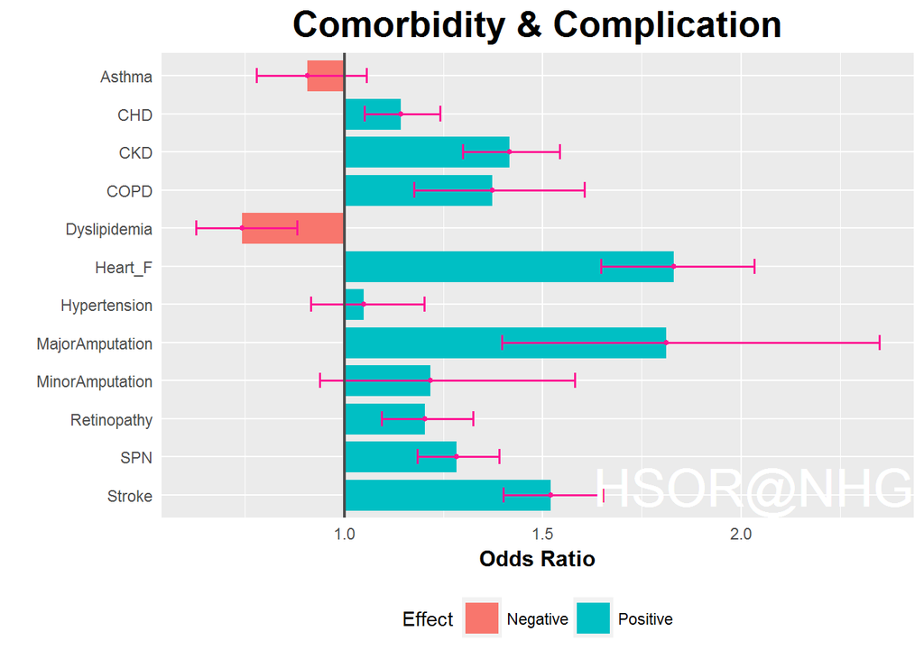

## Model Validation

### Prediction Score Distribution

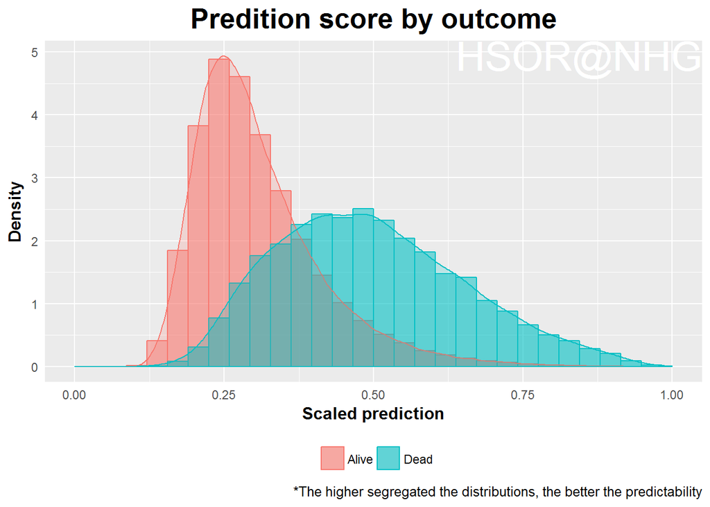

### ROC & AUC

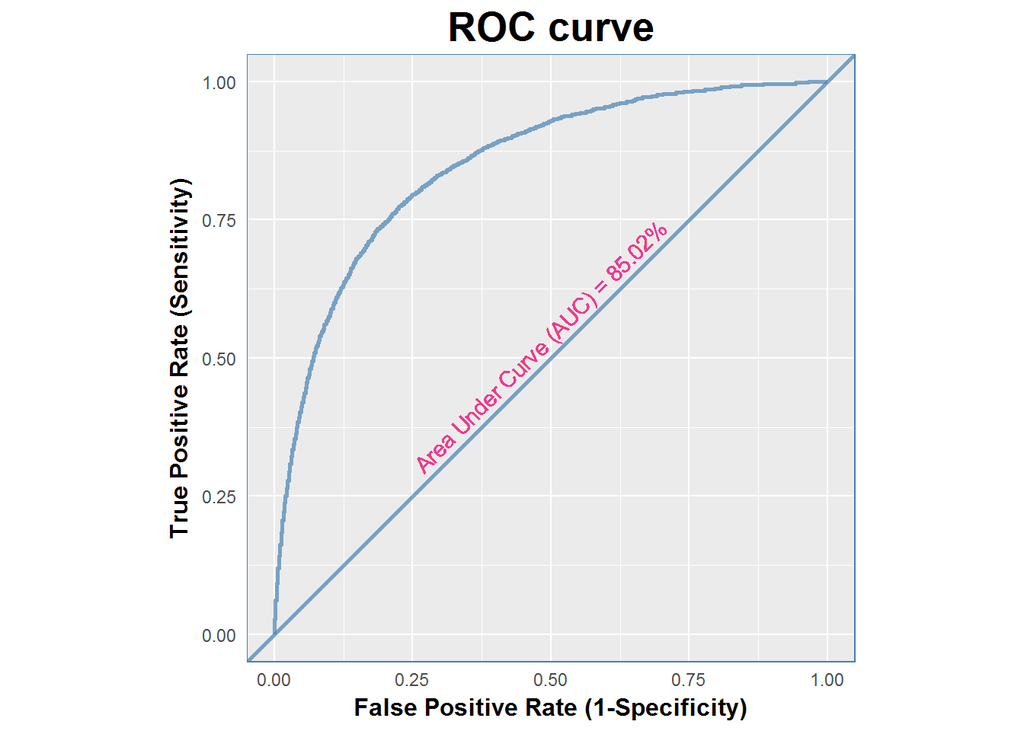

### Fitting performance

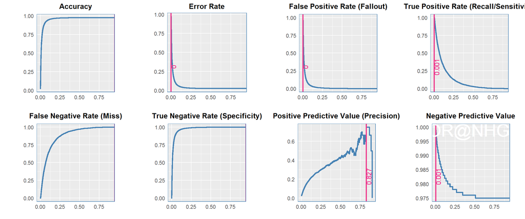

### Fitting performance

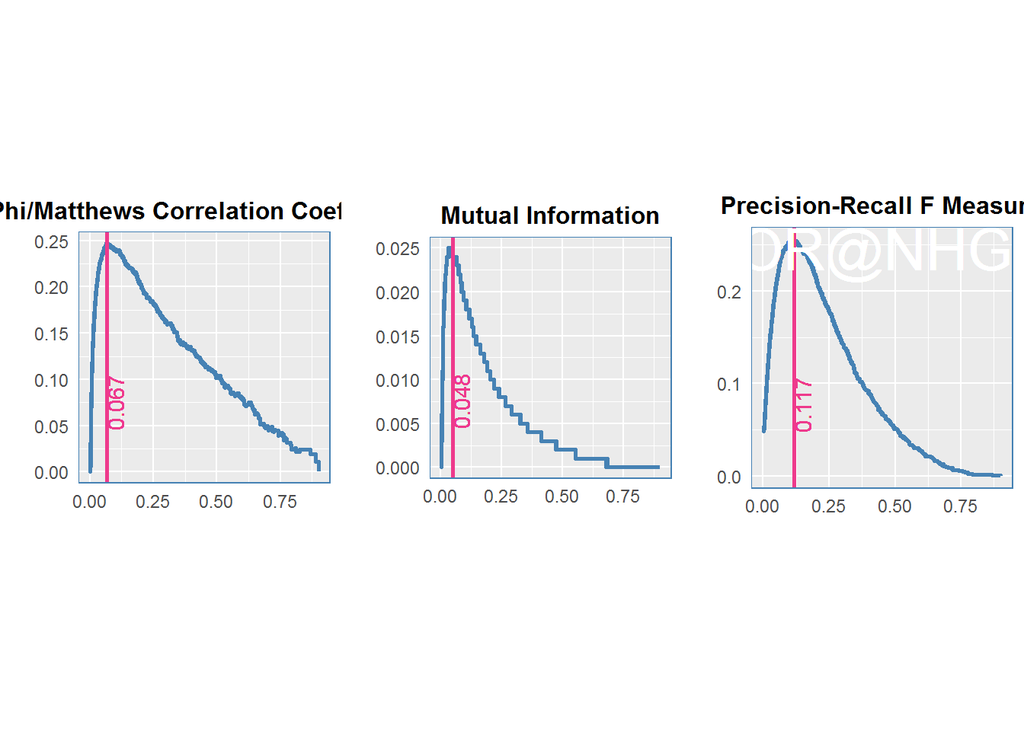

### Lift

How much better if using the prediction compare to pure guess

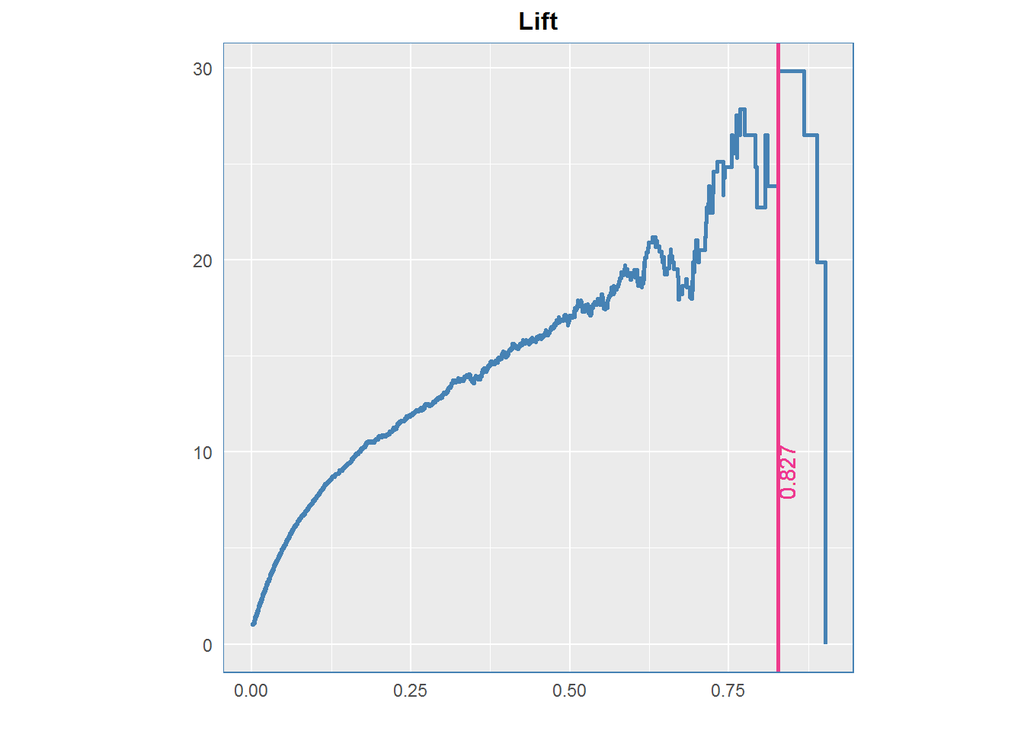